# ISLR Chapter 7

Abhirup Sen

10/05/2021

```r
library(tidyverse)
library(ISLR) # 'Wage' data
library(caret) # cross-validation
```

```r
library(gridExtra) # combining graphs
library(gam) # generalized additive models
library(MASS) # Boston data
select <- dplyr::select

# caret::train with RSS & MSE added:
custom_regression_metrics <- function (data, lev = NULL, model = NULL) {
  c(RMSE = sqrt(mean((data$obs-data$pred)^2)),
    Rsquared = summary(lm(pred ~ obs, data))$r.squared,
    MAE = mean(abs(data$obs-data$pred)),
    MSE = mean((data$obs-data$pred)^2),
    RSS = sum((data$obs-data$pred)^2))
}

RNGkind(kind = "Mersenne-Twister",
        normal.kind = "Inversion",
        sample.kind = "Rejection") # diff versions of R/RMD using different sampling types was annoying me
```

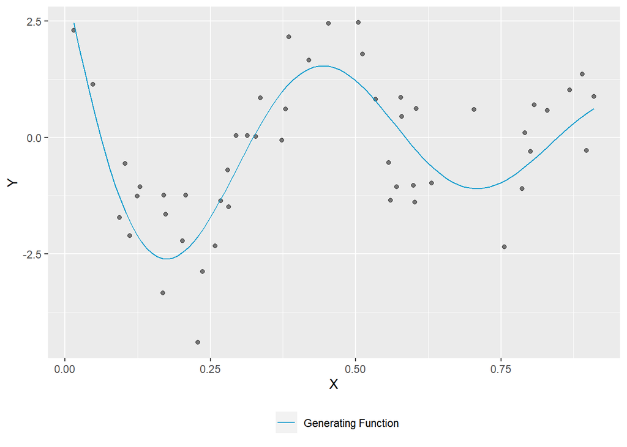

```r
set.seed(3)

X <- runif(50)
eps <- rnorm(50)
Y <- sin(12*(X + 0.2)) / (X + 0.2) + eps
generating_fn <- function(X) {sin(12*(X + 0.2)) / (X + 0.2)}
df <- data.frame(X, Y)

ggplot(df, aes(x = X, y = Y)) +
  geom_point(alpha = 0.5) +
  stat_function(fun = generating_fn, aes(col = "Generating Function")) +
  scale_color_manual(values = "deepskyblue3") +
  theme(legend.position = "bottom", legend.title = element_blank())
```

** (a) Sketch g^ for λ=∞,m=0** Q: λ=∞,m=0

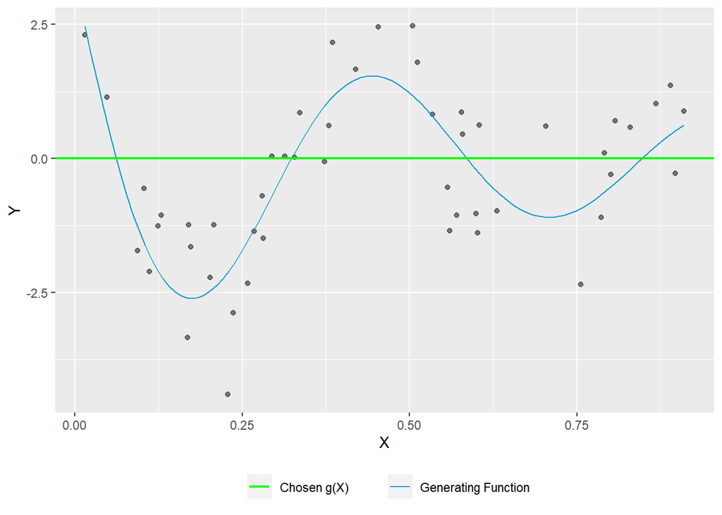

```r
ggplot(df, aes(x = X, y = Y)) +
  geom_point(alpha = 0.5) +
  stat_function(fun = generating_fn, aes(col = "Generating Function")) +
  geom_hline(aes(yintercept = 0, linetype = "Chosen g(X)"), col = "green", size = 0.8) +
  scale_color_manual(values = "deepskyblue3") +
  theme(legend.position = "bottom", legend.title = element_blank())
```

**(b) Sketch g^ for λ=∞,m=1** Q: λ=∞,m=1

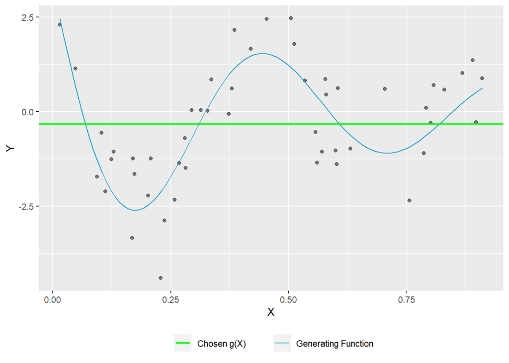

```r
ggplot(df, aes(x = X, y = Y)) +
  geom_point(alpha = 0.5) +
  stat_function(fun = generating_fn, aes(col = "Generating Function")) +
  geom_hline(aes(yintercept = mean(Y), linetype = "Chosen g(X)"), col = "green", size = 0.8) +
  scale_color_manual(values = "deepskyblue3") +
  theme(legend.position = "bottom", legend.title = element_blank())
```

**(c) Sketch g^ for λ=∞,m=2** Q: λ=∞,m=2

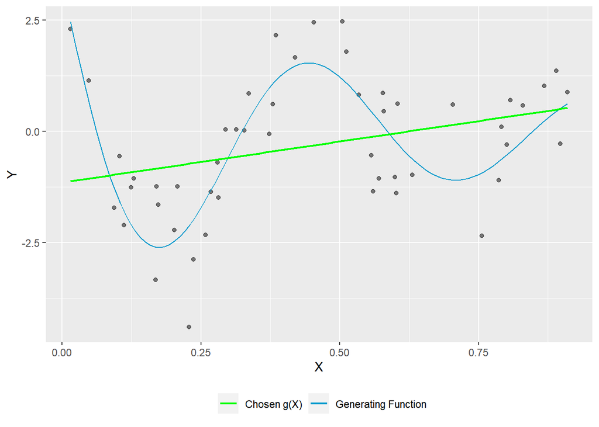

```r
ggplot(df, aes(x = X, y = Y)) +
  geom_point(alpha = 0.5) +
  stat_function(fun = generating_fn, aes(col = "Generating Function")) +
  geom_smooth(method = "lm", formula = "y ~ x", se = F, size = 0.8, aes(col = "Chosen g(X)")) +
  scale_color_manual(values = c("green", "deepskyblue3")) +
  theme(legend.position = "bottom", legend.title = element_blank())
```

** (d) Sketch g^ for λ=∞,m=3** Q: λ=∞,m=3

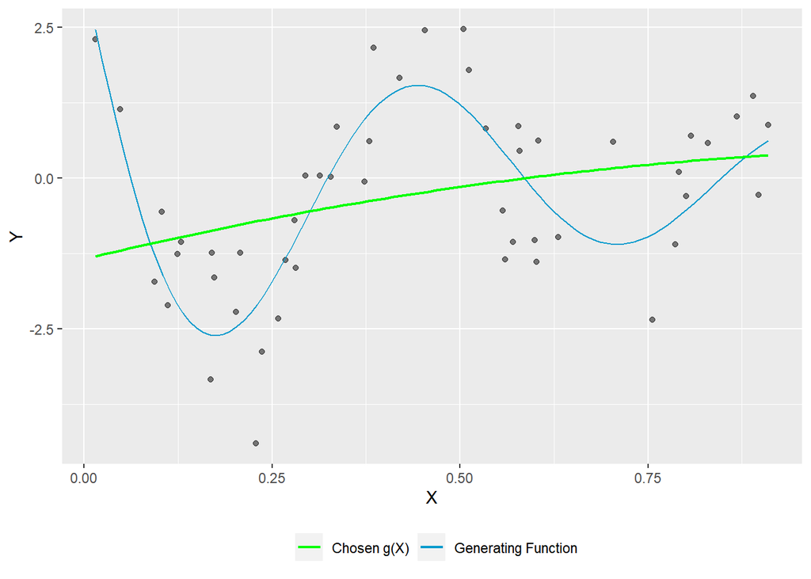

```r
ggplot(df, aes(x = X, y = Y)) +
  geom_point(alpha = 0.5) +
  stat_function(fun = generating_fn, aes(col = "Generating Function")) +
  geom_smooth(method = "lm", formula = "y ~ x + I(x^2)", se = F, size = 0.8, aes(col = "Chosen g(X)")) +
  scale_color_manual(values = c("green", "deepskyblue3")) +
  theme(legend.position = "bottom", legend.title = element_blank())
```

** (e) Sketch g^ for λ=0,m=3 ** Q: λ=0,m=3

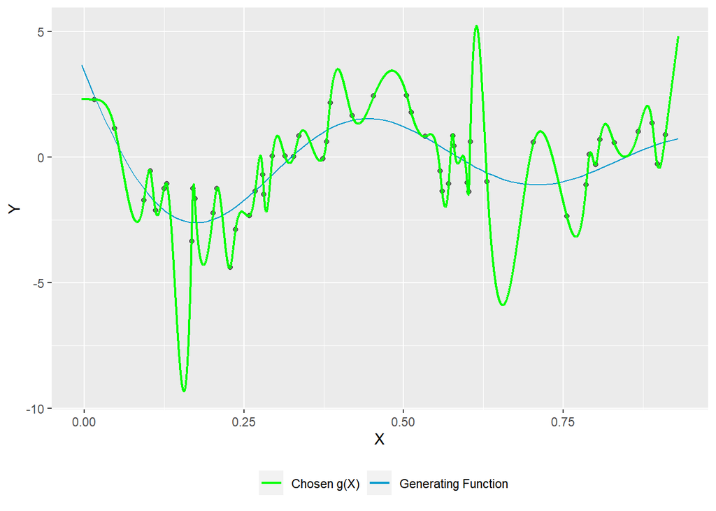

```r
interp_spline <- smooth.spline(x = df$X, y = df$Y, all.knots = T, lambda = 0.0000000000001)
fitted <- predict(interp_spline, x = seq(min(X) - 0.02, max(X) + 0.02, by = 0.0001))
fitted <- data.frame(x = fitted$x, fitted_y = fitted$y)

ggplot(df, aes(x = X, y = Y)) +
  geom_point(alpha = 0.5) +
  stat_function(fun = generating_fn, aes(col = "Generating Function")) +
  geom_line(data = fitted,
            aes(x = x, y = fitted_y, col = "Chosen g(X)"), size = 0.8) +
  scale_color_manual(values = c("green", "deepskyblue3")) +
  theme(legend.position = "bottom", legend.title = element_blank())
```

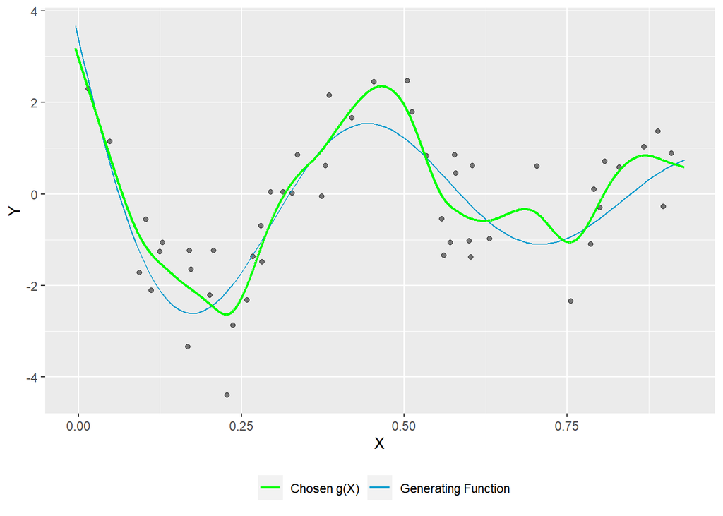

```r
smooth_spline <- smooth.spline(x = df$X, y = df$Y, all.knots = T)
fitted <- predict(smooth_spline, x = seq(min(X) - 0.02, max(X) + 0.02, by = 0.0001))
fitted <- data.frame(x = fitted$x, fitted_y = fitted$y)

ggplot(df, aes(x = X, y = Y)) +
  geom_point(alpha = 0.5) +
  stat_function(fun = generating_fn, aes(col = "Generating Function")) +
  geom_line(data = fitted,
            aes(x = x, y = fitted_y, col = "Chosen g(X)"), size = 0.8) +
  scale_color_manual(values = c("green", "deepskyblue3")) +
  theme(legend.position = "bottom", legend.title = element_blank())
```

**3. Basis Functions - p.1** Q: Suppose we fit a curve with basis functions:

b1(X)=X b2(X)=(X−1)2I(X≥1) (Note that I(X≥1) equals 1 for X≥1 and 0 otherwise.)

We fit the linear regression model

Y=β0+β1b1(X)+β2b2(X)+ϵ

and obtain coefficient estimates β0^=1, β1^=1, β2^=−2. Sketch the estimated curve between X=−2 and X=2. Note the intercepts, slopes, and other relevant information.

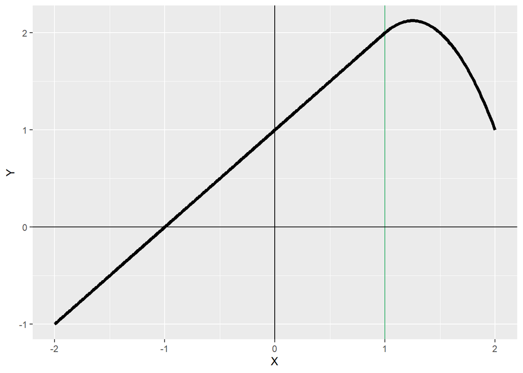

```r
X = seq(-2, 2, 0.01)
Y = 1 + X + -2 * (X - 1)^2 * (X >= 1)
df <- data.frame(X, Y)

ggplot(df, aes(x = X, y = Y)) +
  geom_vline(xintercept = 0) +
  geom_vline(xintercept = 1, col = "mediumseagreen") +
  geom_hline(yintercept = 0) +
  geom_line(size = 1.5)
```

**4. Basis Functions - p.2** Q: Suppose we fit a curve with basis functions:

b1(X)=I(0≤X≤2)−(X−1)I(1≤X≤2) b2(X)=(X−3)I(3≤X≤4)+I(4<X≤5) We fit the linear regression model

Y=β0+β1b1(X)+β2b2(X)+ϵ and obtain coefficient estimates β0^=1, β1^=1, β2^=3. Sketch the estimated curve between X=−2 and X=2. Note the intercepts, slopes, and other relevant information.

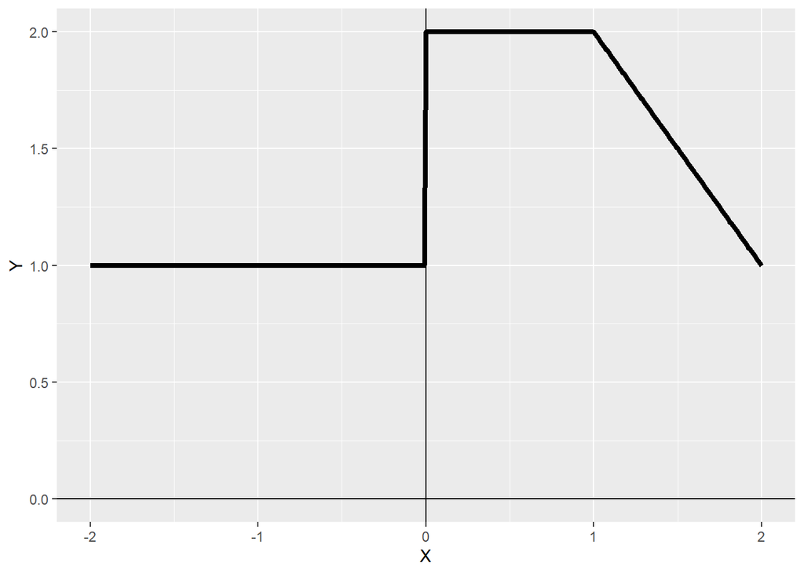

```r
X = seq(-2, 2, 0.01)
Y = 1 + (X >= 0 & X <= 2) - (X - 1)*(X >= 1 & X <= 2) + 3*(X - 3)*(X >= 3 & X <= 4) + 3*(X > 4 & X <= 5)
df <- data.frame(X, Y)

ggplot(df, aes(x = X, y = Y)) +
  geom_vline(xintercept = 0) +
  geom_hline(yintercept = 0) +
  geom_line(size = 1.5)
```

## Problem 6 ** (a) Polynomial Regression**

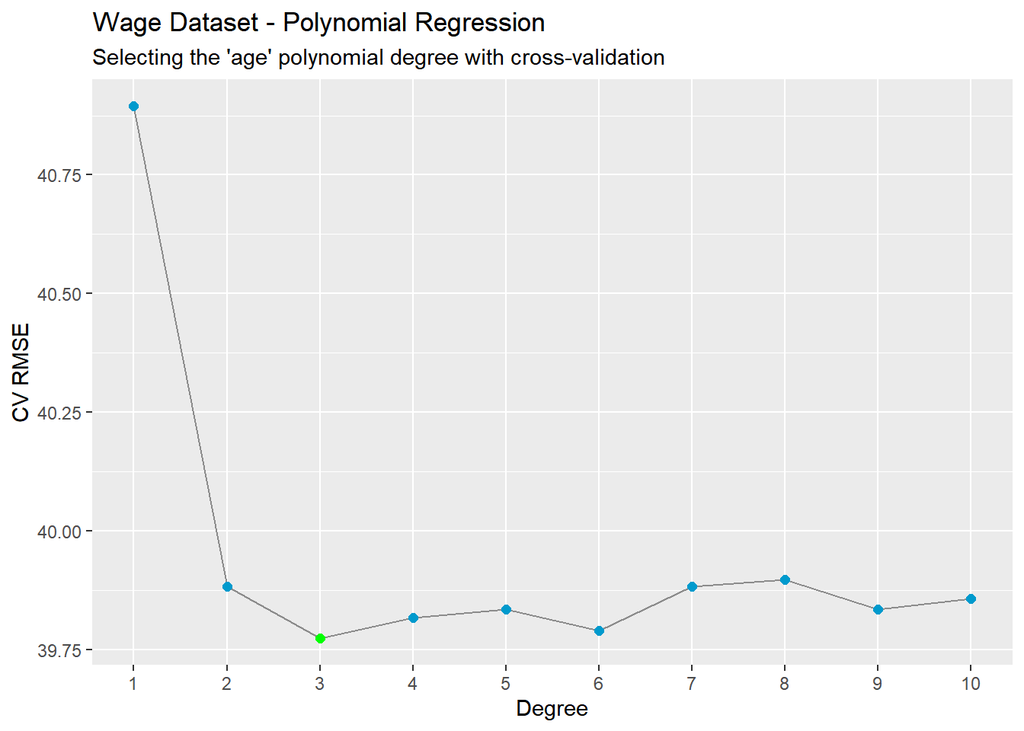

```r
ctrl <- trainControl(method = "cv", number = 10)

CV_RMSE <- c()

set.seed(123)

for (i in 1:10) {
  model_temp <- train(y = Wage$wage,
                      x = poly(Wage$age, i, raw = T, simple = T),
                      method = "lm",
                      metric = "RMSE",
                      trControl = ctrl)
  CV_RMSE[i] <- model_temp$results$RMSE
}


data.frame(degree = 1:10, CV_RMSE = CV_RMSE) %>%
  mutate(min_CV_RMSE = as.numeric(min(CV_RMSE) == CV_RMSE)) %>%
  ggplot(aes(x = degree, y = CV_RMSE)) +
  geom_line(col = "grey55") +
  geom_point(size = 2, aes(col = factor(min_CV_RMSE))) +
  scale_x_continuous(breaks = seq(1, 10), minor_breaks = NULL) +
  scale_color_manual(values = c("deepskyblue3", "green")) +
  theme(legend.position = "none") +
  labs(title = "Wage Dataset - Polynomial Regression",
       subtitle = "Selecting the 'age' polynomial degree with cross-validation",
       x = "Degree",
       y = "CV RMSE")
```

```r
fit.1 <- lm(wage ~ age, data = Wage)
fit.2 <- lm(wage ~ poly(age, 2, raw = T), data = Wage)
fit.3 <- lm(wage ~ poly(age, 3, raw = T), data = Wage)
fit.4 <- lm(wage ~ poly(age, 4, raw = T), data = Wage)
fit.5 <- lm(wage ~ poly(age, 5, raw = T), data = Wage)

anova(fit.1, fit.2, fit.3, fit.4, fit.5)
```

```
## Analysis of Variance Table
##
## Model 1: wage ~ age
## Model 2: wage ~ poly(age, 2, raw = T)
## Model 3: wage ~ poly(age, 3, raw = T)
## Model 4: wage ~ poly(age, 4, raw = T)
## Model 5: wage ~ poly(age, 5, raw = T)
##   Res.Df     RSS Df Sum of Sq        F    Pr(>F)
## 1   2998 5022216
## 2   2997 4793430  1    228786 143.5931 < 2.2e-16 ***
## 3   2996 4777674  1     15756   9.8888  0.001679 **
## 4   2995 4771604  1      6070   3.8098  0.051046 .
## 5   2994 4770322  1      1283   0.8050  0.369682
## ---
## Signif. codes:  0 '***' 0.001 '**' 0.01 '*' 0.05 '.' 0.1 ' ' 1
```

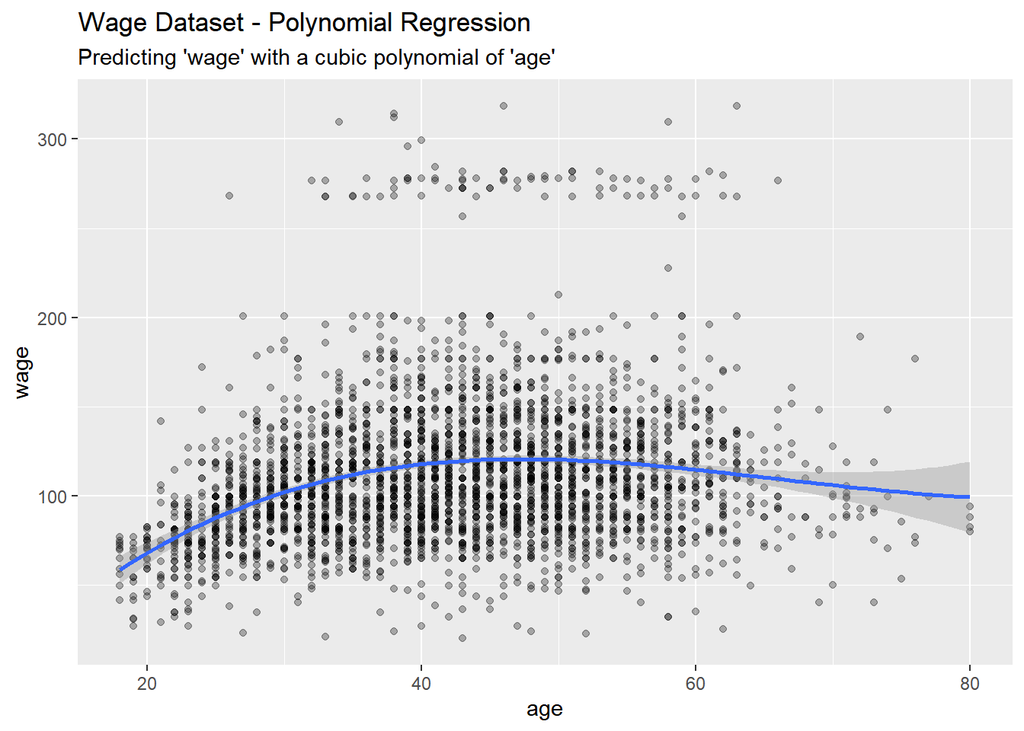

```r
ggplot(Wage, aes(x = age, y = wage)) +
  geom_point(alpha = 0.3) +
  geom_smooth(method = "lm", formula = "y ~ poly(x, 3, raw = T)") +
  labs(title = "Wage Dataset - Polynomial Regression",
       subtitle = "Predicting 'wage' with a cubic polynomial of 'age'")
```

**(b) Step Function**

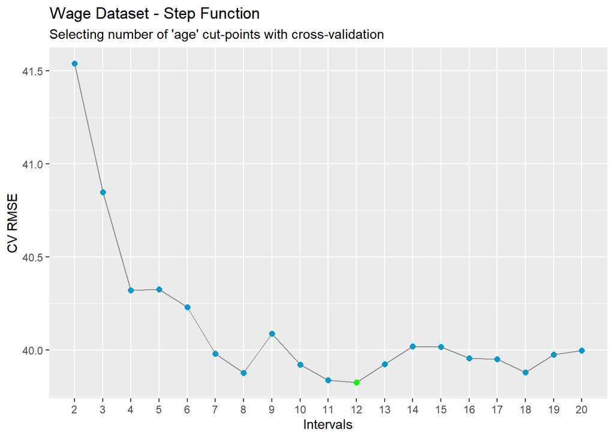

```r
CV_RMSE <- c()

set.seed(124)

for (i in 2:20) {
  model_temp <- train(y = Wage$wage,
                      x = data.frame(cut(Wage$age, i)),
                      method = "lm",
                      metric = "RMSE",
                      trControl = ctrl)
  CV_RMSE[i-1] <- model_temp$results$RMSE
}


data.frame(cuts = 2:20, CV_RMSE = CV_RMSE) %>%
  mutate(min_CV_RMSE = as.numeric(min(CV_RMSE) == CV_RMSE)) %>%
  ggplot(aes(x = cuts, y = CV_RMSE)) +
  geom_line(col = "grey55") +
  geom_point(size = 2, aes(col = factor(min_CV_RMSE))) +
  scale_x_continuous(breaks = seq(2, 20), minor_breaks = NULL) +
  scale_color_manual(values = c("deepskyblue3", "green")) +
  theme(legend.position = "none") +
  labs(title = "Wage Dataset - Step Function",
       subtitle = "Selecting number of 'age' cut-points with cross-validation",
       x = "Intervals",
       y = "CV RMSE")
```

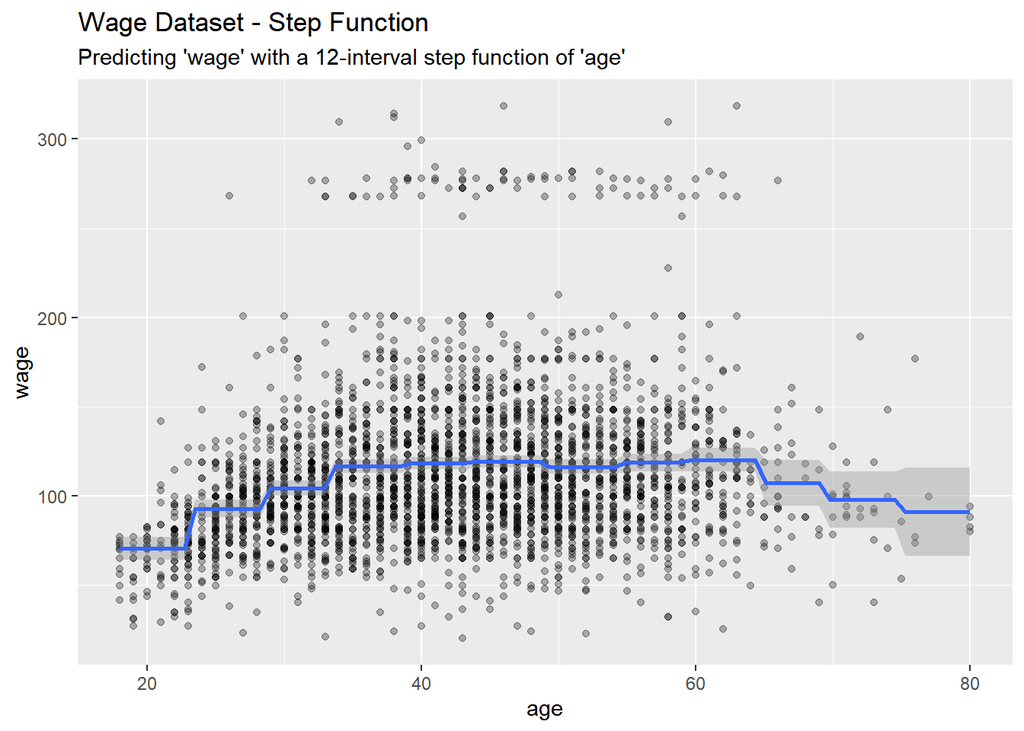

```r
ggplot(Wage, aes(x = age, y = wage)) +
  geom_point(alpha = 0.3) +
  geom_smooth(method = "lm", formula = "y ~ cut(x, 12)") +
  labs(title = "Wage Dataset - Step Function",
       subtitle = "Predicting 'wage' with a 12-interval step function of 'age'")
```

##Problem 7

```r
glimpse(Wage)
```

```
## Rows: 3,000
## Columns: 11
## $ year       <int> 2006, 2004, 2003, 2003, 2005, 2008, 2009, 2008, 2006, 2004,~
## $ age        <int> 18, 24, 45, 43, 50, 54, 44, 30, 41, 52, 45, 34, 35, 39, 54,~
## $ maritl     <fct> 1. Never Married, 1. Never Married, 2. Married, 2. Married,~
## $ race       <fct> 1. White, 1. White, 1. White, 3. Asian, 1. White, 1. White,~
## $ education  <fct> 1. < HS Grad, 4. College Grad, 3. Some College, 4. College ~
## $ region     <fct> 2. Middle Atlantic, 2. Middle Atlantic, 2. Middle Atlantic,~
## $ jobclass   <fct> 1. Industrial, 2. Information, 1. Industrial, 2. Informatio~
## $ health     <fct> 1. <=Good, 2. >=Very Good, 1. <=Good, 2. >=Very Good, 1. <=~
## $ health_ins <fct> 2. No, 2. No, 1. Yes, 1. Yes, 1. Yes, 1. Yes, 1. Yes, 1. Ye~
## $ logwage    <dbl> 4.318063, 4.255273, 4.875061, 5.041393, 4.318063, 4.845098,~
## $ wage       <dbl> 75.04315, 70.47602, 130.98218, 154.68529, 75.04315, 127.115~
```

```r
table(Wage$year)
```

```
##
## 2003 2004 2005 2006 2007 2008 2009
##  513  485  447  392  386  388  389
```

```r
table(cut(Wage$year, breaks = 2002:2009))
```

```
##
## (2002,2003] (2003,2004] (2004,2005] (2005,2006] (2006,2007] (2007,2008]
##         513         485         447         392         386         388
## (2008,2009]
##         389
```

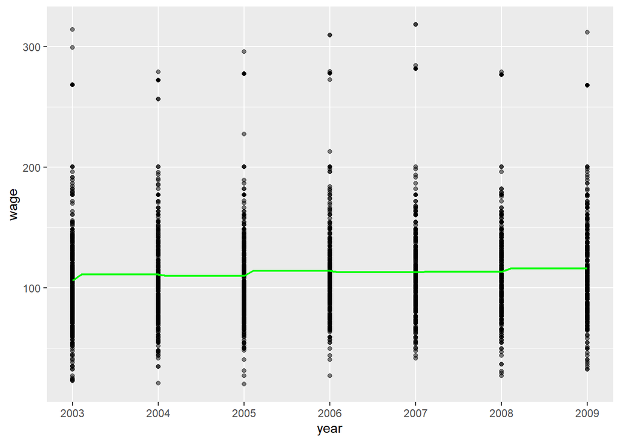

```r
year_step <- lm(wage ~ cut(year, breaks = 2002:2009), Wage)
fitted <- data.frame(year = seq(2003, 2009, 0.1),
                     wage = predict(year_step, data.frame(year = seq(2003, 2009, 0.1))))


ggplot(Wage, aes(x = year, y = wage)) +
  geom_point(alpha = 0.5) +
  geom_line(data = fitted,
            aes(x = year, y = wage), size = 0.8, col = "green") +
  scale_x_continuous(breaks = 2003:2009, minor_breaks = NULL)
```

```r
table(Wage$maritl)
```

```
##
## 1. Never Married       2. Married       3. Widowed      4. Divorced
##              648             2074               19              204
##     5. Separated
##               55
```

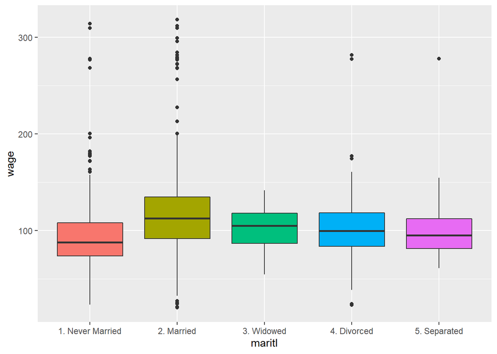

```r
ggplot(Wage, aes(x = maritl, y = wage, fill = maritl)) +
  geom_boxplot() +
  theme(legend.position = "none")
```

```r
table(Wage$race)
```

```
##
## 1. White 2. Black 3. Asian 4. Other
##     2480      293      190       37
```

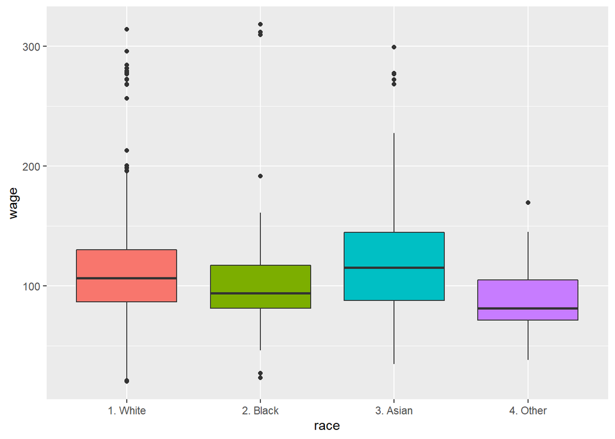

```r
ggplot(Wage, aes(x = race, y = wage, fill = race)) +
  geom_boxplot() +
  theme(legend.position = "none")
```

```r
table(Wage$education)
```

```
##
##       1. < HS Grad         2. HS Grad    3. Some College    4. College Grad
##                268                971                650                685
## 5. Advanced Degree
##                426
```

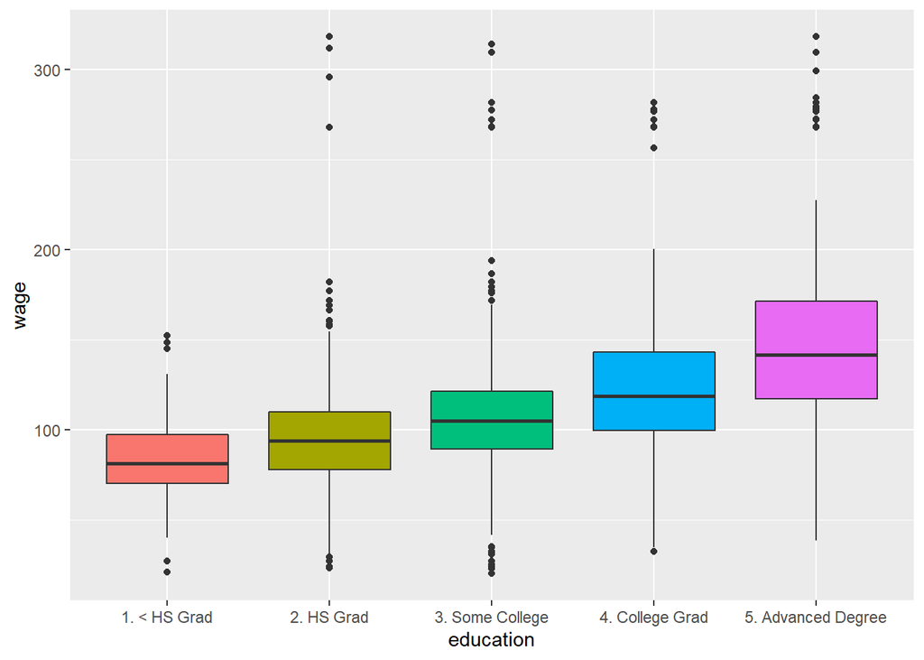

```r
ggplot(Wage, aes(x = education, y = wage, fill = education)) +
  geom_boxplot() +
  theme(legend.position = "none")
```

```r
table(Wage$region)
```

```
##
##        1. New England    2. Middle Atlantic 3. East North Central
##                     0                  3000                     0
## 4. West North Central     5. South Atlantic 6. East South Central
##                     0                     0                     0
## 7. West South Central           8. Mountain            9. Pacific
##                     0                     0                     0
```

```r
table(Wage$jobclass)
```

```
##
##  1. Industrial 2. Information
##           1544           1456
```

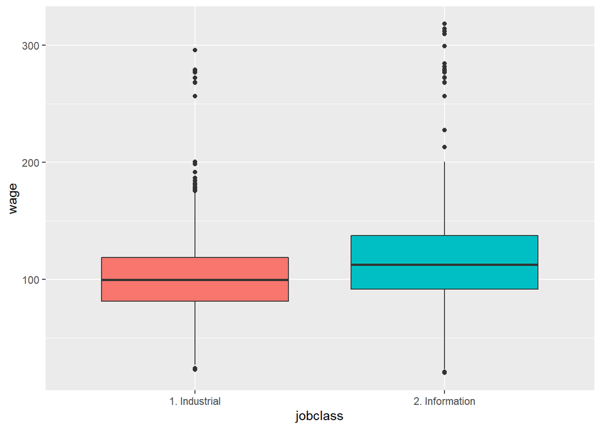

```r
ggplot(Wage, aes(x = jobclass, y = wage, fill = jobclass)) +
  geom_boxplot() +
  theme(legend.position = "none")
```

```r
table(Wage$health)
```

```
##
##      1. <=Good 2. >=Very Good
##            858           2142
```

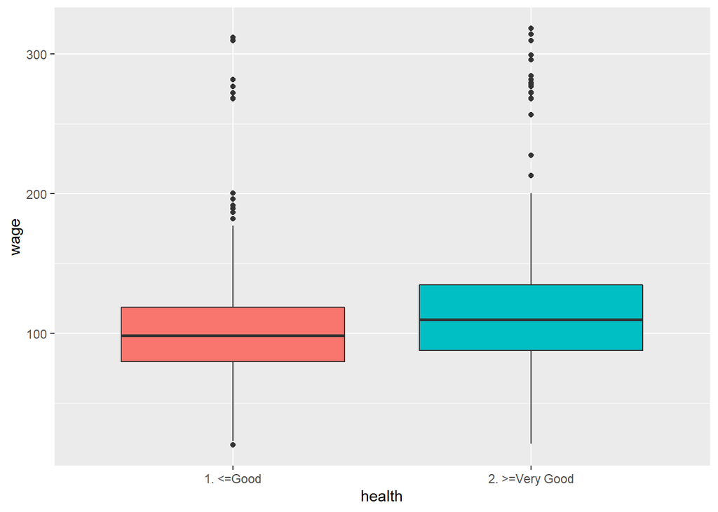

```r
ggplot(Wage, aes(x = health, y = wage, fill = health)) +
  geom_boxplot() +
  theme(legend.position = "none")
```

```r
table(Wage$health_ins)
```

```
##
## 1. Yes  2. No
##   2083    917
```

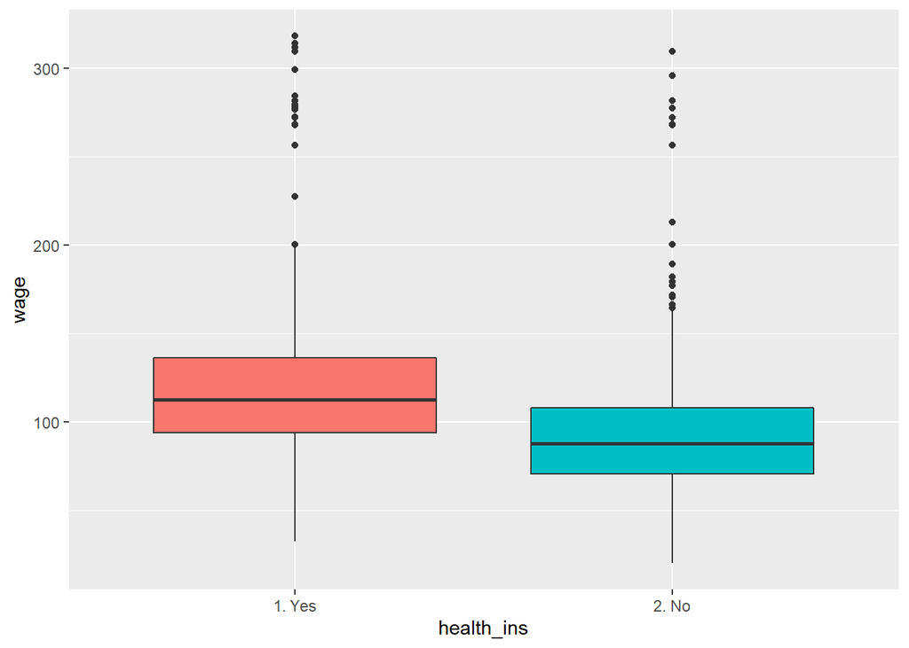

```r
ggplot(Wage, aes(x = health_ins, y = wage, fill = health_ins)) +
  geom_boxplot() +
  theme(legend.position = "none")
```

```r
Wage_cleaned <- Wage %>%
  select(wage, age, year, maritl, race, education, region, jobclass, health, health_ins) %>%
  mutate(maritl = case_when(maritl %in% c("3. Widowed", "4. Divorced") ~ "6. Previously Married", TRUE ~ as.character(maritl)) %>% factor(),
         race = case_when(race %in% c("2. Black", "4. Other") ~ "5. Black & Other", TRUE ~ as.character(race)) %>% factor())


model <- lm(wage ~ poly(age, 3, raw = T) + cut(year, breaks = 2002:2009) + maritl + race + education + jobclass + health + health_ins, data = Wage_cleaned)
summary(model)
```

```
##
## Call:
## lm(formula = wage ~ poly(age, 3, raw = T) + cut(year, breaks = 2002:2009) +
##     maritl + race + education + jobclass + health + health_ins,
##     data = Wage_cleaned)
##
## Residuals:
##    Min     1Q Median     3Q    Max
## -101.4  -18.6   -3.3   13.8  209.2
##
## Coefficients:
##                                            Estimate Std. Error t value Pr(>|t|)
## (Intercept)                               3.187e+00  1.972e+01   0.162 0.871596
## poly(age, 3, raw = T)1                    3.592e+00  1.409e+00   2.550 0.010832
## poly(age, 3, raw = T)2                   -4.883e-02  3.190e-02  -1.530 0.126009
## poly(age, 3, raw = T)3                    1.634e-04  2.321e-04   0.704 0.481443
## cut(year, breaks = 2002:2009)(2003,2004]  2.603e+00  2.145e+00   1.214 0.224950
## cut(year, breaks = 2002:2009)(2004,2005]  3.122e+00  2.190e+00   1.426 0.154054
## cut(year, breaks = 2002:2009)(2005,2006]  7.629e+00  2.269e+00   3.362 0.000782
## cut(year, breaks = 2002:2009)(2006,2007]  5.201e+00  2.281e+00   2.280 0.022658
## cut(year, breaks = 2002:2009)(2007,2008]  6.408e+00  2.274e+00   2.818 0.004866
## cut(year, breaks = 2002:2009)(2008,2009]  8.393e+00  2.275e+00   3.689 0.000229
## maritl2. Married                          1.337e+01  1.811e+00   7.385 1.98e-13
## maritl5. Separated                        7.160e+00  4.857e+00   1.474 0.140521
## maritl6. Previously Married               1.629e-01  2.845e+00   0.057 0.954348
## race3. Asian                             -2.683e+00  2.587e+00  -1.037 0.299772
## race5. Black & Other                     -4.856e+00  2.022e+00  -2.402 0.016374
## education2. HS Grad                       7.564e+00  2.351e+00   3.218 0.001306
## education3. Some College                  1.799e+01  2.499e+00   7.200 7.59e-13
## education4. College Grad                  3.064e+01  2.531e+00  12.107  < 2e-16
## education5. Advanced Degree               5.315e+01  2.793e+00  19.031  < 2e-16
## jobclass2. Information                    3.455e+00  1.317e+00   2.623 0.008750
## health2. >=Very Good                      6.310e+00  1.412e+00   4.469 8.14e-06
## health_ins2. No                          -1.634e+01  1.404e+00 -11.635  < 2e-16
##
## (Intercept)
## poly(age, 3, raw = T)1                   *
## poly(age, 3, raw = T)2
## poly(age, 3, raw = T)3
## cut(year, breaks = 2002:2009)(2003,2004]
```

[output cut: 8 more lines]

```
## race3. Asian
## race5. Black & Other                     *
## education2. HS Grad                      **
## education3. Some College                 ***
## education4. College Grad                 ***
## education5. Advanced Degree              ***
## jobclass2. Information                   **
## health2. >=Very Good                     ***
## health_ins2. No                          ***
## ---
## Signif. codes:  0 '***' 0.001 '**' 0.01 '*' 0.05 '.' 0.1 ' ' 1
##
## Residual standard error: 33.75 on 2978 degrees of freedom
## Multiple R-squared:  0.3503, Adjusted R-squared:  0.3457
## F-statistic: 76.44 on 21 and 2978 DF,  p-value: < 2.2e-16
```

##Problem 8

```r
glimpse(Auto)
```

```
## Rows: 392
## Columns: 9
## $ mpg          <dbl> 18, 15, 18, 16, 17, 15, 14, 14, 14, 15, 15, 14, 15, 14, 2~
## $ cylinders    <dbl> 8, 8, 8, 8, 8, 8, 8, 8, 8, 8, 8, 8, 8, 8, 4, 6, 6, 6, 4, ~
## $ displacement <dbl> 307, 350, 318, 304, 302, 429, 454, 440, 455, 390, 383, 34~
## $ horsepower   <dbl> 130, 165, 150, 150, 140, 198, 220, 215, 225, 190, 170, 16~
## $ weight       <dbl> 3504, 3693, 3436, 3433, 3449, 4341, 4354, 4312, 4425, 385~
## $ acceleration <dbl> 12.0, 11.5, 11.0, 12.0, 10.5, 10.0, 9.0, 8.5, 10.0, 8.5, ~
## $ year         <dbl> 70, 70, 70, 70, 70, 70, 70, 70, 70, 70, 70, 70, 70, 70, 7~
## $ origin       <dbl> 1, 1, 1, 1, 1, 1, 1, 1, 1, 1, 1, 1, 1, 1, 3, 1, 1, 1, 3, ~
## $ name         <fct> chevrolet chevelle malibu, buick skylark 320, plymouth sa~
```

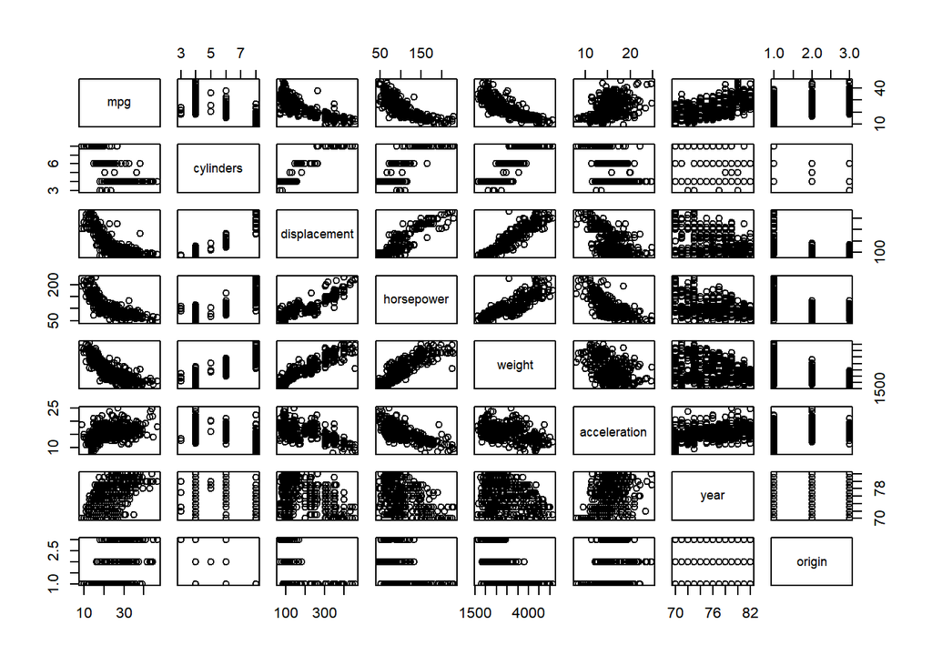

```r
pairs(Auto[ ,-9])
```

```r
Auto$origin <- factor(Auto$origin, labels = c("American", "European", "Japanese"))

Auto$brand <- sapply(strsplit(as.character(Auto$name), split = " "),
                     function(x) x[1]) # extract the first item from each list element

Auto$brand <- factor(ifelse(Auto$brand %in% c("vokswagen", "vw"), "volkswagen",
                     ifelse(Auto$brand == "toyouta", "toyota",
                            ifelse(Auto$brand %in% c("chevroelt", "chevy"), "chevrolet",
                                   ifelse(Auto$brand == "maxda", "mazda",
                                          Auto$brand))))) # fixing typo's

Auto$brand <- fct_lump(Auto$brand,
                       n = 9,
                       other_level = "uncommon") # collapse into 10 categories

Auto$name <- NULL

glimpse(Auto)
```

```
## Rows: 392
## Columns: 9
## $ mpg          <dbl> 18, 15, 18, 16, 17, 15, 14, 14, 14, 15, 15, 14, 15, 14, 2~
## $ cylinders    <dbl> 8, 8, 8, 8, 8, 8, 8, 8, 8, 8, 8, 8, 8, 8, 4, 6, 6, 6, 4, ~
## $ displacement <dbl> 307, 350, 318, 304, 302, 429, 454, 440, 455, 390, 383, 34~
## $ horsepower   <dbl> 130, 165, 150, 150, 140, 198, 220, 215, 225, 190, 170, 16~
## $ weight       <dbl> 3504, 3693, 3436, 3433, 3449, 4341, 4354, 4312, 4425, 385~
## $ acceleration <dbl> 12.0, 11.5, 11.0, 12.0, 10.5, 10.0, 9.0, 8.5, 10.0, 8.5, ~
## $ year         <dbl> 70, 70, 70, 70, 70, 70, 70, 70, 70, 70, 70, 70, 70, 70, 7~
## $ origin       <fct> American, American, American, American, American, America~
## $ brand        <fct> chevrolet, buick, plymouth, amc, ford, ford, chevrolet, p~
```

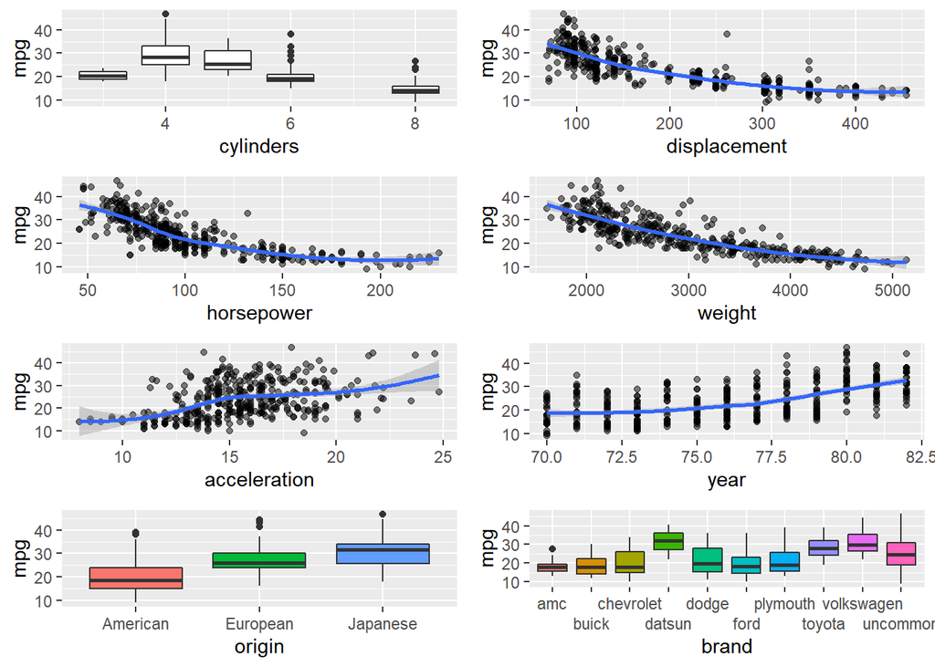

```r
g1 <- ggplot(Auto, aes(x = cylinders, y = mpg, group = cylinders)) +
  geom_boxplot()

g2 <- ggplot(Auto, aes(x = displacement, y = mpg)) +
  geom_point(alpha = 0.5) +
  geom_smooth()

g3 <- ggplot(Auto, aes(x = horsepower, y = mpg)) +
  geom_point(alpha = 0.5) +
  geom_smooth()

g4 <- ggplot(Auto, aes(x = weight, y = mpg)) +
  geom_point(alpha = 0.5) +
  geom_smooth()

g5 <- ggplot(Auto, aes(x = acceleration, y = mpg)) +
  geom_point(alpha = 0.5) +
  geom_smooth()

g6 <- ggplot(Auto, aes(x = year, y = mpg)) +
  geom_point(alpha = 0.5) +
  geom_smooth()

g7 <- ggplot(Auto, aes(x = origin, y = mpg, fill = origin)) +
  geom_boxplot() +
  theme(legend.position = "none")

g8 <- ggplot(Auto, aes(x = brand, y = mpg, fill = brand)) +
  geom_boxplot() +
  scale_x_discrete(guide = guide_axis(n.dodge = 2)) +
  theme(legend.position = "none")

grid.arrange(g1, g2, g3, g4, g5, g6, g7, g8, ncol = 2)
```

**liner Regression

```r
ctrl <- trainControl(method = "repeatedcv", number = 10, repeats = 3)

set.seed(1)

model_linear <- train(mpg ~ .,
                      data = Auto,
                      method = "lm",
                      metric = "Rsquared",
                      trControl = ctrl)

model_linear$results$Rsquared
```

```
## [1] 0.8239898
```

**Smoothing Spline:**

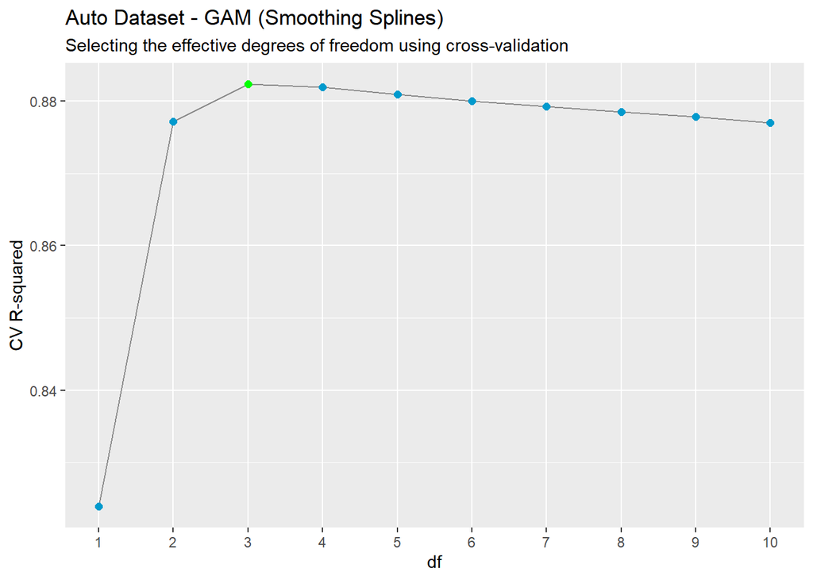

```r
set.seed(1)

model_smoothspline_broad <- train(mpg ~ .,
                                  data = Auto,
                                  method = "gamSpline",
                                  metric = "Rsquared",
                                  trControl = ctrl,
                                  tuneGrid = data.frame(df = 1:10))

data.frame(df = 1:10, CV_R2 = model_smoothspline_broad$results$Rsquared) %>%
  mutate(max_CV_R2 = as.numeric(max(CV_R2) == CV_R2)) %>%
  ggplot(aes(x = df, y = CV_R2)) +
  geom_line(col = "grey55") +
  geom_point(size = 2, aes(col = factor(max_CV_R2))) +
  scale_x_continuous(breaks = seq(1, 10), minor_breaks = NULL) +
  scale_color_manual(values = c("deepskyblue3", "green")) +
  theme(legend.position = "none") +
  labs(title = "Auto Dataset - GAM (Smoothing Splines)",
       subtitle = "Selecting the effective degrees of freedom using cross-validation",
       x = "df",
       y = "CV R-squared")
```

**The cross-validation R2:**

```r
max(model_smoothspline_broad$results$Rsquared)
```

```
## [1] 0.8823149
```

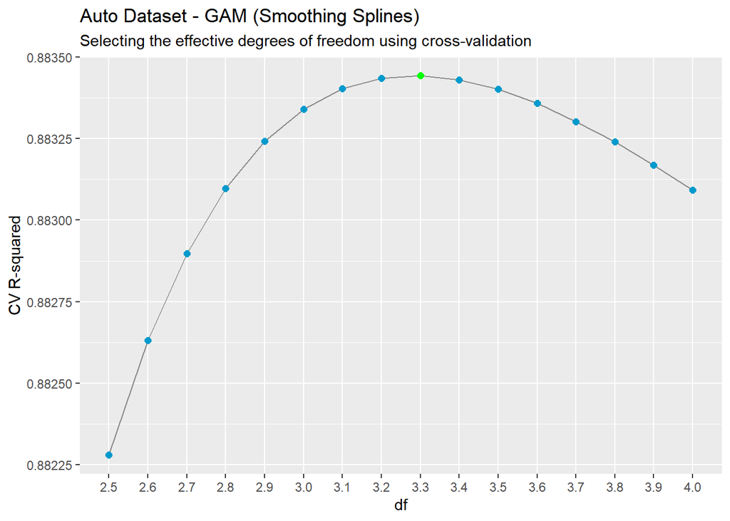

```r
model_smoothspline_fine <- train(mpg ~ .,
                            data = Auto,
                            method = "gamSpline",
                            metric = "Rsquared",
                            trControl = ctrl,
                            tuneGrid = data.frame(df = seq(2.5, 4, 0.1)))

data.frame(df = seq(2.5, 4, 0.1), CV_R2 = model_smoothspline_fine$results$Rsquared) %>%
  mutate(max_CV_R2 = as.numeric(max(CV_R2) == CV_R2)) %>%
  ggplot(aes(x = df, y = CV_R2)) +
  geom_line(col = "grey55") +
  geom_point(size = 2, aes(col = factor(max_CV_R2))) +
  scale_x_continuous(breaks = seq(2.5, 4, 0.1), minor_breaks = NULL) +
  scale_color_manual(values = c("deepskyblue3", "green")) +
  theme(legend.position = "none") +
  labs(title = "Auto Dataset - GAM (Smoothing Splines)",
       subtitle = "Selecting the effective degrees of freedom using cross-validation",
       x = "df",
       y = "CV R-squared")
```

## Problem 9

** Cubic Polynomial

```r
model <- lm(nox ~ poly(dis, 3, raw = T), data = Boston)
summary(model)
```

```
##
## Call:
## lm(formula = nox ~ poly(dis, 3, raw = T), data = Boston)
##
## Residuals:
##       Min        1Q    Median        3Q       Max
## -0.121130 -0.040619 -0.009738  0.023385  0.194904
##
## Coefficients:
##                          Estimate Std. Error t value Pr(>|t|)
## (Intercept)             0.9341281  0.0207076  45.110  < 2e-16 ***
## poly(dis, 3, raw = T)1 -0.1820817  0.0146973 -12.389  < 2e-16 ***
## poly(dis, 3, raw = T)2  0.0219277  0.0029329   7.476 3.43e-13 ***
## poly(dis, 3, raw = T)3 -0.0008850  0.0001727  -5.124 4.27e-07 ***
## ---
## Signif. codes:  0 '***' 0.001 '**' 0.01 '*' 0.05 '.' 0.1 ' ' 1
##
## Residual standard error: 0.06207 on 502 degrees of freedom
## Multiple R-squared:  0.7148, Adjusted R-squared:  0.7131
## F-statistic: 419.3 on 3 and 502 DF,  p-value: < 2.2e-16
```

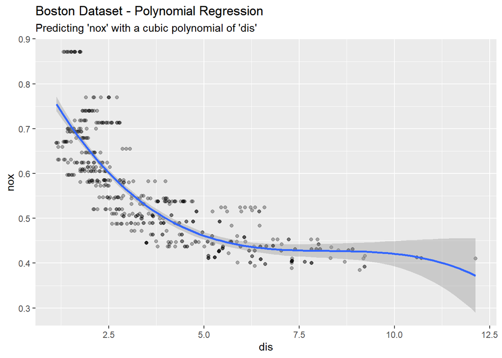

```r
ggplot(Boston, aes(x = dis, y = nox)) +
  geom_point(alpha = 0.3) +
  geom_smooth(method = "lm", formula = "y ~ poly(x, 3, raw = T)") +
  labs(title = "Boston Dataset - Polynomial Regression",
       subtitle = "Predicting 'nox' with a cubic polynomial of 'dis'")
```

**(b) Polynomial Regression - Training MSE**

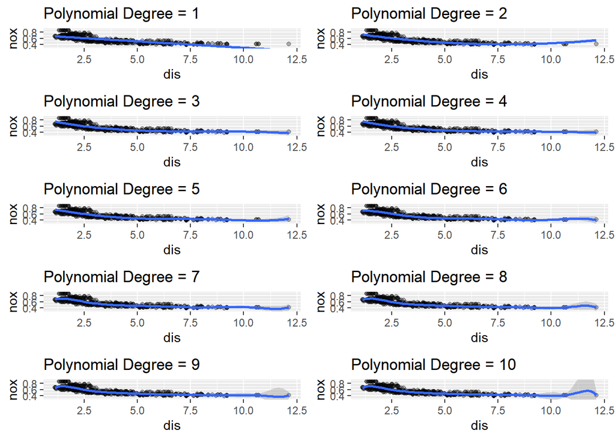

```r
g1 <- ggplot(Boston, aes(x = dis, y = nox)) +
  geom_point(alpha = 0.3) +
  geom_smooth(method = "lm", formula = "y ~ poly(x, 1, raw = T)") +
  coord_cartesian(ylim = c(0.3, 0.9)) +
  labs(title = "Polynomial Degree = 1")

g2 <- ggplot(Boston, aes(x = dis, y = nox)) +
  geom_point(alpha = 0.3) +
  geom_smooth(method = "lm", formula = "y ~ poly(x, 2, raw = T)") +
  coord_cartesian(ylim = c(0.3, 0.9)) +
  labs(title = "Polynomial Degree = 2")

g3 <- ggplot(Boston, aes(x = dis, y = nox)) +
  geom_point(alpha = 0.3) +
  geom_smooth(method = "lm", formula = "y ~ poly(x, 3, raw = T)") +
  coord_cartesian(ylim = c(0.3, 0.9)) +
  labs(title = "Polynomial Degree = 3")

g4 <- ggplot(Boston, aes(x = dis, y = nox)) +
  geom_point(alpha = 0.3) +
  geom_smooth(method = "lm", formula = "y ~ poly(x, 4, raw = T)") +
  coord_cartesian(ylim = c(0.3, 0.9)) +
  labs(title = "Polynomial Degree = 4")

g5 <- ggplot(Boston, aes(x = dis, y = nox)) +
  geom_point(alpha = 0.3) +
  geom_smooth(method = "lm", formula = "y ~ poly(x, 5, raw = T)") +
  coord_cartesian(ylim = c(0.3, 0.9)) +
  labs(title = "Polynomial Degree = 5")

g6 <- ggplot(Boston, aes(x = dis, y = nox)) +
  geom_point(alpha = 0.3) +
  geom_smooth(method = "lm", formula = "y ~ poly(x, 6, raw = T)") +
  coord_cartesian(ylim = c(0.3, 0.9)) +
  labs(title = "Polynomial Degree = 6")

g7 <- ggplot(Boston, aes(x = dis, y = nox)) +
  geom_point(alpha = 0.3) +
  geom_smooth(method = "lm", formula = "y ~ poly(x, 7, raw = T)") +
  coord_cartesian(ylim = c(0.3, 0.9)) +
  labs(title = "Polynomial Degree = 7")

g8 <- ggplot(Boston, aes(x = dis, y = nox)) +
  geom_point(alpha = 0.3) +
  geom_smooth(method = "lm", formula = "y ~ poly(x, 8, raw = T)") +
  coord_cartesian(ylim = c(0.3, 0.9)) +
  labs(title = "Polynomial Degree = 8")

g9 <- ggplot(Boston, aes(x = dis, y = nox)) +
  geom_point(alpha = 0.3) +
  geom_smooth(method = "lm", formula = "y ~ poly(x, 9, raw = T)") +
  coord_cartesian(ylim = c(0.3, 0.9)) +
  labs(title = "Polynomial Degree = 9")

g10 <- ggplot(Boston, aes(x = dis, y = nox)) +
  geom_point(alpha = 0.3) +
  geom_smooth(method = "lm", formula = "y ~ poly(x, 10, raw = T)") +
  coord_cartesian(ylim = c(0.3, 0.9)) +
  labs(title = "Polynomial Degree = 10")

grid.arrange(g1, g2, g3, g4, g5, g6, g7, g8, g9, g10, ncol = 2)
```

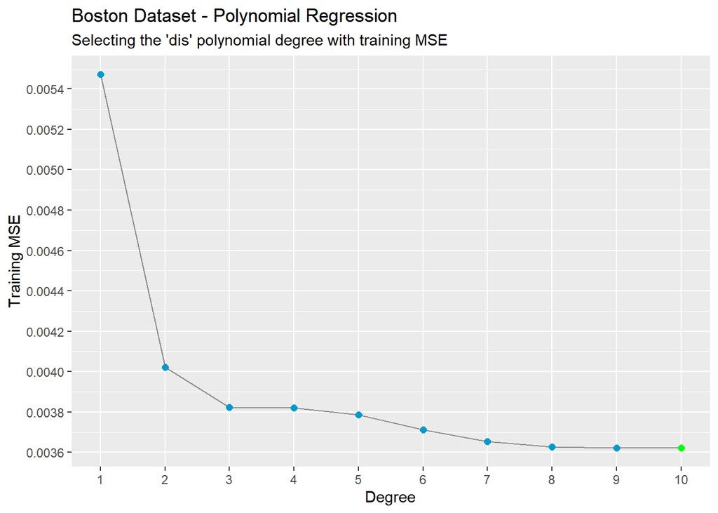

```r
train_MSE <- c()

for (i in 1:10) {
    model_temp <- lm(nox ~ poly(dis, i, raw = T), data = Boston)
    train_MSE[i] <- mean(model_temp$residuals^2)
}

data.frame(degree = 1:10, train_MSE) %>%
  mutate(min_train_MSE = as.numeric(min(train_MSE) == train_MSE)) %>%
  ggplot(aes(x = degree, y = train_MSE)) +
  geom_line(col = "grey55") +
  geom_point(size = 2, aes(col = factor(min_train_MSE))) +
  scale_x_continuous(breaks = 1:10, minor_breaks = NULL) +
  scale_y_continuous(breaks = seq(0, 0.2, 0.0002)) +
  scale_color_manual(values = c("deepskyblue3", "green")) +
  theme(legend.position = "none") +
  labs(title = "Boston Dataset - Polynomial Regression",
       subtitle = "Selecting the 'dis' polynomial degree with training MSE",
       x = "Degree",
       y = "Training MSE")
```

**(c) Polynomial Regression - Tuning Degree (CV MSE)**

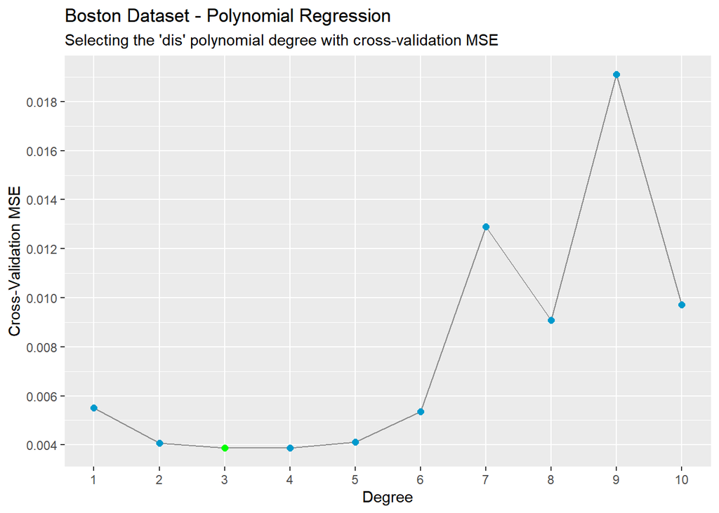

```r
ctrl <- trainControl(method = "repeatedcv", number = 10, repeats = 5, summaryFunction = custom_regression_metrics)

CV_MSE <- c()

set.seed(159)

for (i in 1:10) {
  model_temp <- train(y = Boston$nox,
                      x = poly(Boston$dis, i, raw = T, simple = T),
                      method = "lm",
                      metric = "MSE",
                      trControl = ctrl)
  CV_MSE[i] <- model_temp$results$MSE
}

data.frame(degree = 1:10, CV_MSE = CV_MSE) %>%
  mutate(min_CV_MSE = as.numeric(min(CV_MSE) == CV_MSE)) %>%
  ggplot(aes(x = degree, y = CV_MSE)) +
  geom_line(col = "grey55") +
  geom_point(size = 2, aes(col = factor(min_CV_MSE))) +
  scale_x_continuous(breaks = seq(1, 10), minor_breaks = NULL) +
  scale_y_continuous(breaks = seq(0, 0.03, 0.002)) +
  scale_color_manual(values = c("deepskyblue3", "green")) +
  theme(legend.position = "none") +
  labs(title = "Boston Dataset - Polynomial Regression",
       subtitle = "Selecting the 'dis' polynomial degree with cross-validation MSE",
       x = "Degree",
       y = "Cross-Validation MSE")
```

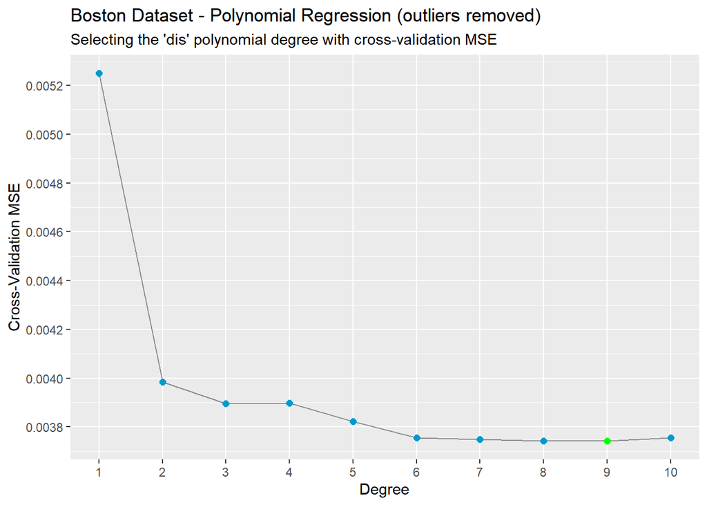

```r
ctrl <- trainControl(method = "repeatedcv", number = 10, repeats = 5, summaryFunction = custom_regression_metrics)

Boston1 <- Boston %>%
  filter(dis < 10)

CV_MSE <- c()

set.seed(159)

for (i in 1:10) {
  model_temp <- train(y = Boston1$nox,
                      x = poly(Boston1$dis, i, raw = T, simple = T),
                      method = "lm",
                      metric = "MSE",
                      trControl = ctrl)
  CV_MSE[i] <- model_temp$results$MSE
}

data.frame(degree = 1:10, CV_MSE = CV_MSE) %>%
  mutate(min_CV_MSE = as.numeric(min(CV_MSE) == CV_MSE)) %>%
  ggplot(aes(x = degree, y = CV_MSE)) +
  geom_line(col = "grey55") +
  geom_point(size = 2, aes(col = factor(min_CV_MSE))) +
  scale_x_continuous(breaks = seq(1, 10), minor_breaks = NULL) +
  scale_y_continuous(breaks = seq(0, 0.2, 0.0002)) +
  scale_color_manual(values = c("deepskyblue3", "green")) +
  theme(legend.position = "none") +
  labs(title = "Boston Dataset - Polynomial Regression (outliers removed)",
       subtitle = "Selecting the 'dis' polynomial degree with cross-validation MSE",
       x = "Degree",
       y = "Cross-Validation MSE")
```

**(d) Different Splines & Knots**

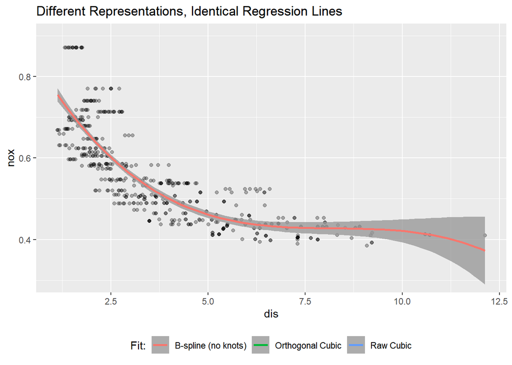

```r
ggplot(Boston, aes(x = dis, y = nox)) +
  geom_vline(xintercept = attr(bs(Boston$dis, df = 3),"knots"), col = "grey55", linetype = "dashed") +
  geom_point(alpha = 0.3) +
  geom_smooth(method = "lm", formula = "y ~ poly(x, 3)", aes(col = "Orthogonal Cubic")) +
  geom_smooth(method = "lm", formula = "y ~ poly(x, 3, raw = T)", aes(col = "Raw Cubic")) +
  geom_smooth(method = "lm", formula = "y ~ bs(x, df = 3)", aes(col = "B-spline (no knots)")) + # note the identical fit to the cubics
  coord_cartesian(ylim = c(0.3, 0.9)) +
  theme(legend.position = "bottom") +
  labs(title = "Different Representations, Identical Regression Lines", col = "Fit:")
```

```r
head(poly(Boston$dis, 3))
```

```
##                1           2           3
## [1,] 0.006233255 -0.04136207  0.03495452
## [2,] 0.024768778 -0.04614946  0.01039356
## [3,] 0.024768778 -0.04614946  0.01039356
## [4,] 0.047911237 -0.03413142 -0.02986110
## [5,] 0.047911237 -0.03413142 -0.02986110
## [6,] 0.047911237 -0.03413142 -0.02986110
```

```r
head(poly(Boston$dis, 3, raw = T))
```

```
##           1        2         3
## [1,] 4.0900 16.72810  68.41793
## [2,] 4.9671 24.67208 122.54870
## [3,] 4.9671 24.67208 122.54870
## [4,] 6.0622 36.75027 222.78748
## [5,] 6.0622 36.75027 222.78748
## [6,] 6.0622 36.75027 222.78748
```

```r
head(bs(Boston$dis, df = 3))
```

```
##              1         2          3
## [1,] 0.4313152 0.1588833 0.01950924
## [2,] 0.4437231 0.2378394 0.04249466
## [3,] 0.4437231 0.2378394 0.04249466
## [4,] 0.4092114 0.3328457 0.09024369
## [5,] 0.4092114 0.3328457 0.09024369
## [6,] 0.4092114 0.3328457 0.09024369
```

```r
identical(predict(lm(nox ~ poly(dis, 3), Boston)) %>% round(10),
          predict(lm(nox ~ poly(dis, 3, raw = T), Boston)) %>% round(10),
          predict(lm(nox ~ bs(dis, df = 3), Boston)) %>% round(10))
```

```
## [1] TRUE
```